# Quiz5_inclass

Clara Mugnai

2/23/2022

“All work presented is my own. I have not communicated with or worked with anyone else on this quiz.”

Clara Mugnai

Collaboration Reminder: You may not communicate with or work with anyone else on this quiz, but you may use any of our course materials or materials on the Internet.

Question 1 (7 points). Consider the following two bar plots using the palmerpenguins data set. The first is a plot of the penguin species while the second is a plot of the average bill length for each species.

```r
library(palmerpenguins)
library(tidyverse)
```

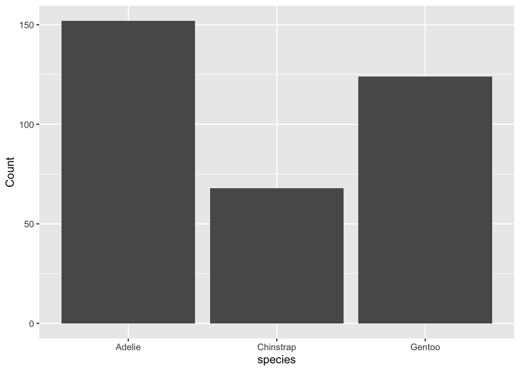

```r
ggplot(data = penguins, aes(x = species)) +
  geom_bar() +
  labs(y = "Count")
```

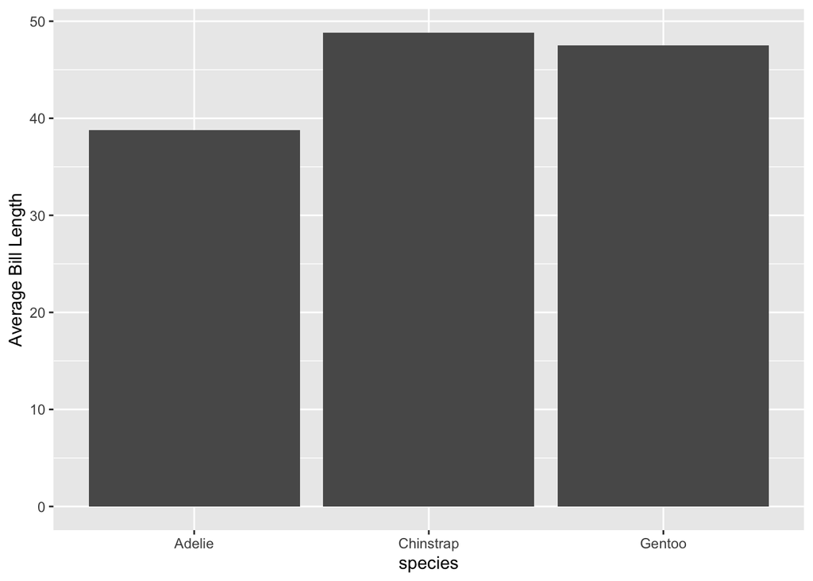

```r
ggplot(data = penguins %>% group_by(species) %>%
         summarise(avg_length = mean(bill_length_mm, na.rm = TRUE)),
       aes(x = species, y = avg_length)) +
  geom_col() +
  labs(y = "Average Bill Length")
```

Which of the two graphs is appropriate to construct? Give a one sentence reason.

- The first plot is appropriate, with the counts, because we have established you should not create a plot with no way to show variation for a summary statistic like a mean.

Question 2 (9 points). Use the Happy Planet Index data set to construct a graph that does not properly show variability in the underlying data. Recall that some variables in this data set are LifeExpectancy, Wellbeing, Footprint, and Region of the world.

```r
library(here)
hpi_df <- read_csv(here("data/hpi-tidy.csv"))
```

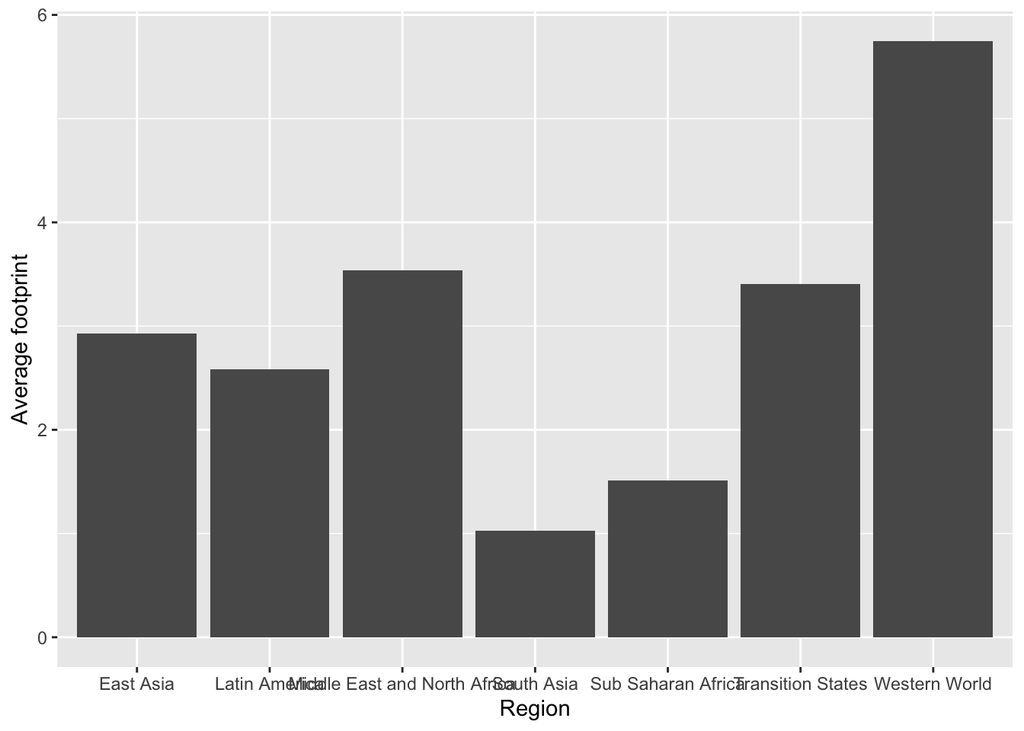

```r
ggplot(data = hpi_df %>% group_by(Region) %>%
         summarise(avg_footprint = mean(Footprint, na.rm = TRUE)),
       aes(x = Region, y = avg_footprint)) +
  geom_col() +
  labs(y = "Average footprint")
```

Question 3 (7 points). Fix your graph from the previous question so that it does properly show variability in the underlying data.

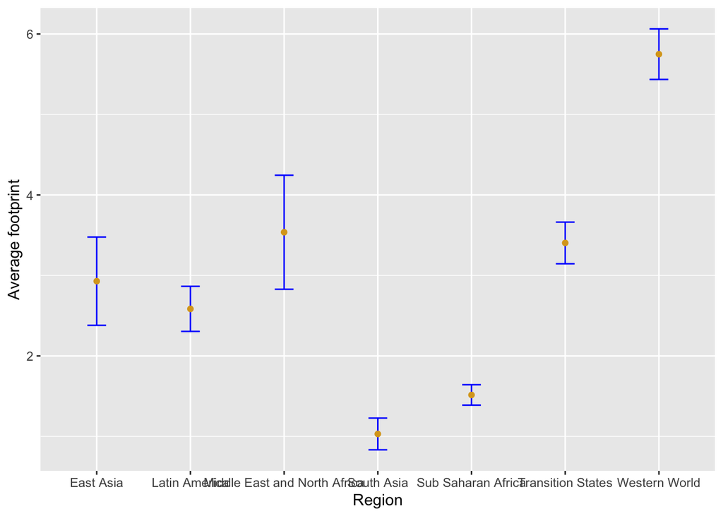

```r
hpi_variability <- hpi_df %>% group_by(Region) %>%
         summarise(avg_footprint = mean(Footprint, na.rm = TRUE), sdfootprint = sd(Footprint), ncountries = n()) %>%
    mutate(l_se = avg_footprint - sdfootprint / sqrt(ncountries),
           u_se = avg_footprint + sdfootprint / sqrt(ncountries))

ggplot(data = hpi_variability, aes(x = Region, y = avg_footprint)) +
  geom_errorbar(aes(ymin=l_se, ymax=u_se), width=.2,
                 position=position_dodge(.9), color = "blue") + geom_point(color = "goldenrod") +
  labs(y = "Average footprint")
```

The remaining 2 points are given for committing and pushing your .Rmd and .html files correctly to GitHub.